# Gene-level model for 53 GTEX transcriptomes

### Prediction performance on the median absolute expression levels across tissues.

The predicted log2-TPM values for 2,705 genes coded on chromosome 1 were compared with the actual median log2-TPMs across 53 tissues.

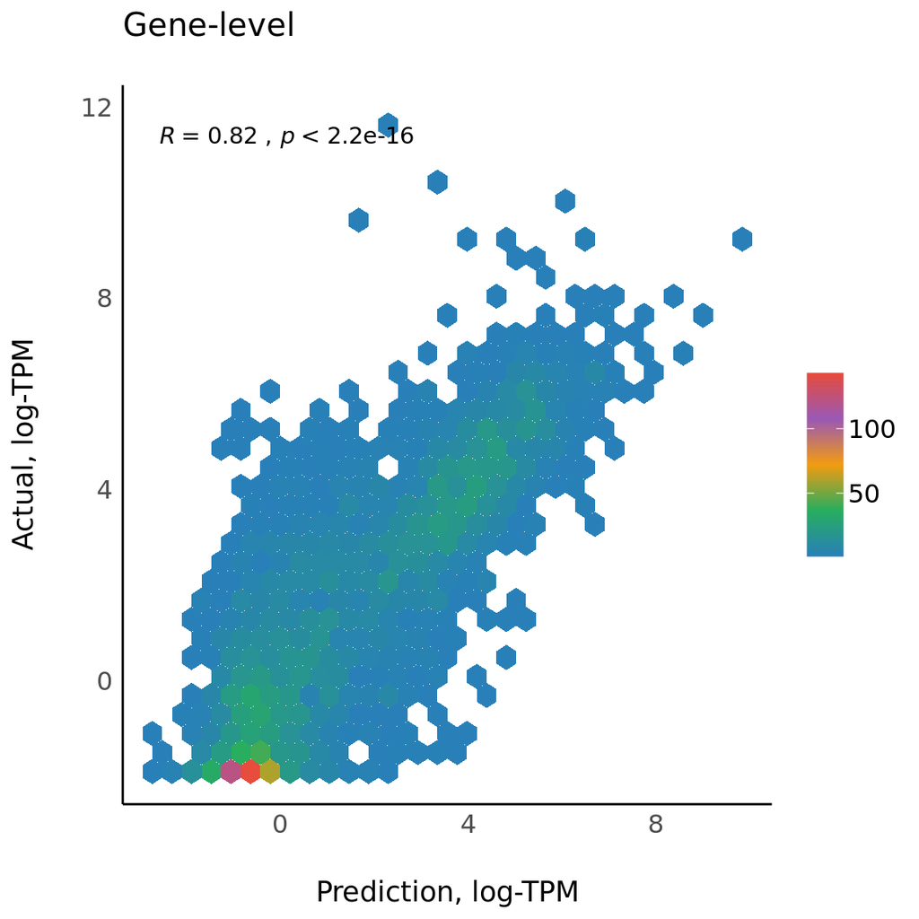

```r
# p - Median scatter ####
ds <- readRDS("../data/01_tissue_gene/DEcode_model/test_Chr1/pred.rds")

# gene-level ###
ds%>%
  filter(tissue%in%"MedianExp")%>%
  filter(model=="Promoter & RNA features")%>%
  ggplot(.,aes(pred,actual))+
  geom_hex()+
  scale_fill_flat_c(name="") +
  theme_modern()+
  stat_cor(method="spearman")+
  ggtitle("Gene-level")+
  xlab("Prediction, log-TPM")+
  ylab("Actual, log-TPM") -> p
plot(p)
```

### Prediction performance for the fold-change across 53 tissues.

The predicted fold-change for 2,705 genes coded on chromosome 1 were compared with the actual fold-change across 53 tissues.

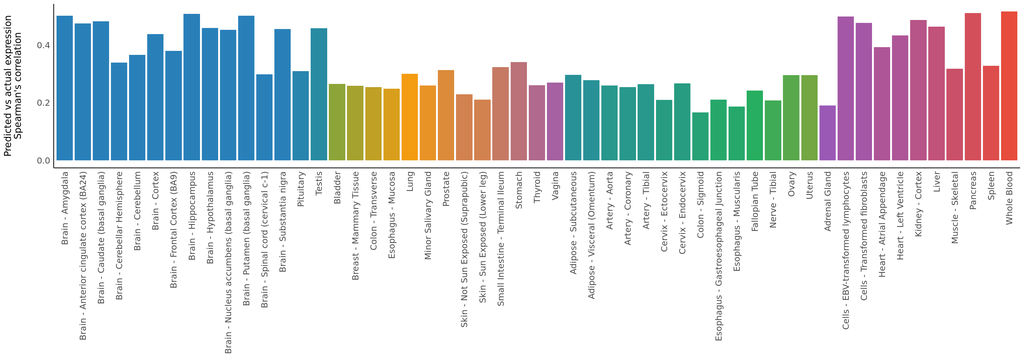

```r
ds <- readRDS("../data/01_tissue_gene/DEcode_model/test_Chr1/pred.rds")
ds$tissue=ds$tissue%>%rename_tissue_bar()
cor_to_brain <- readRDS("./functions/cluster_color.rds")

ds%>%
  filter(tissue!="Median expression",
         model=="Promoter & RNA features")%>%
  group_by(tissue)%>%
  do(cor.test(.$actual,.$pred,method = "spearman")%>%broom::tidy())%>%
  ungroup()%>%
  mutate(tissue=factor(tissue,levels = cor_to_brain$key))%>%
  ggplot(.,aes(tissue,estimate,fill=tissue))+
  geom_bar(stat="identity",position = "dodge")+
  scale_fill_manual(values = cor_to_brain%>%.$color) +
  #scale_fill_flat_d()+
  theme_modern()+
  ylab("Predicted vs actual expression\nSpearman's correlation")+
  theme(axis.text.x = element_text(angle = 90, hjust = 1,vjust = 0.5),
        legend.position = "none")+
  xlab(NULL)+
  scale_y_continuous(breaks = scales::pretty_breaks(n = 3))-> p

plot(p)
```

### Pairwise correlations between the predicted and the actual tissue-specific expression

The heatmap showing pairwise correlations between the predicted and the actual tissue-specific expression profiles of 53 tissues for the testing genes.

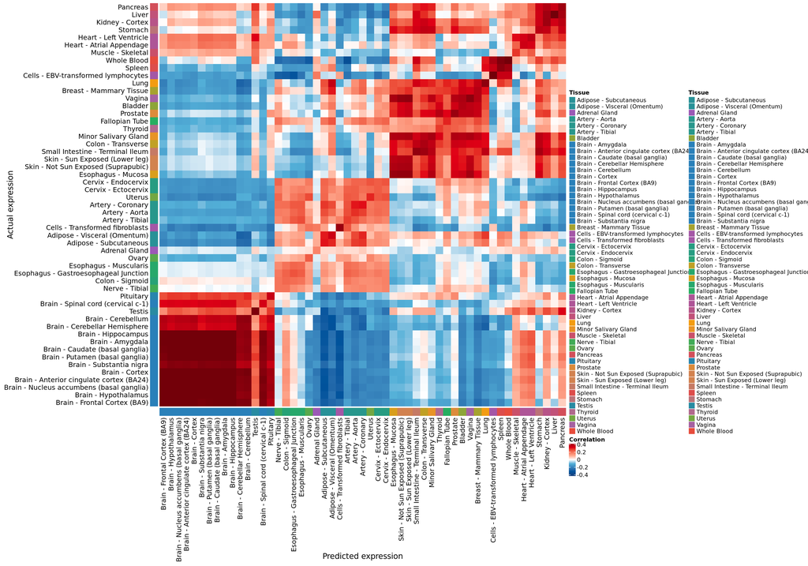

```r
# p - Tissue heatmap ####
ds <- readRDS("../data/01_tissue_gene/DEcode_model/test_Chr1/pred.rds")

# acutal expression
ds%>%
  filter(tissue!="MedianExp")%>%
  dplyr::select(gene,tissue,actual)%>%
  filter(!duplicated(paste0(gene,tissue)))%>%
  spread(tissue,actual) -> mat
mat_actual=mat[,-1]%>%as.matrix()
rownames(mat_actual)=mat$gene

# predicted expression
ds%>%
  filter(tissue!="MedianExp")%>%
  filter(model=="Promoter & RNA features")%>%
  dplyr::select(gene,tissue,pred)%>%
  spread(tissue,pred) -> mat
mat_pred=mat[,-1]%>%as.matrix()
rownames(mat_pred)=mat$gene


jet.colors <- colorRampPalette(c("#00007F", "#007FFF", "cyan",
                                 "#7FFF7F", "yellow", "#FF7F00", "red"))
col_pos = jet.colors(7)

# calc correlation between acutal and prediction
cor_between_pred_actual=cor(mat_actual,mat_pred)
colnames(cor_between_pred_actual)=colnames(cor_between_pred_actual)%>%rename_tissue_bar()
rownames(cor_between_pred_actual)=rownames(cor_between_pred_actual)%>%rename_tissue_bar()

# get predefined tissue color
alphabet_order <- readRDS("./functions/cluster_color.rds")
tissue_color=alphabet_order$color
names(tissue_color)=alphabet_order$key

# make column and row annotation
tc = columnAnnotation(Tissue = names(tissue_color),
                      col = list(Tissue = tissue_color),
                      show_annotation_name = FALSE)
ha = rowAnnotation(Tissue = names(tissue_color),
                   col = list(Tissue = tissue_color),
                   show_annotation_name = FALSE)

# cluster correlation matrix
indx=match(names(tissue_color),colnames(cor_between_pred_actual))
cor_between_pred_actual=cor_between_pred_actual[indx,indx]
hc_rows=hclust(d = dist(cor_between_pred_actual),method = "ward.D2")

# generate heatmap
ht = Heatmap(cor_between_pred_actual,
             name="Correlation",
             cluster_rows = rev(as.dendrogram(hc_rows)),
             cluster_columns = hc_rows,
             left_annotation = ha,
             bottom_annotation = tc,
             col = g2_colorRamp2(values =c(-0.5,-0.3,-0.1,
                                           0,
                                           0.1,0.3,0.5 )),
             column_title="Predicted expression",
             column_title_side="bottom",
             row_title="Actual expression",
             show_row_names = TRUE,
             row_names_side = "left",
             show_row_dend = FALSE,
             show_column_dend = FALSE,
             column_names_max_height = unit(20,"cm"),
             row_names_max_width = unit(20,"cm"))
draw(ht)
```

```r
# DEcode
list.files(path = "../data/01_tissue_gene/DEcode_model/test_Chr8/",
           pattern = "pred.rds",full.names = T,recursive = T)%>%
  lapply(., function(x){
    ds=readRDS(x)
    ds%>%
      mutate(run = dirname(x)%>%basename())%>%
      return()
  })%>%bind_rows() -> ds

# compute correlation between acutal and prediction
ds%>%
  group_by(tissue,run)%>%
  do(cor.test(.$actual,.$pred)%>%broom::tidy())%>%
  mutate(model="DEcode")-> res_cor

# compute RMSE between acutal and prediction
ds%>%
  group_by(tissue,run)%>%
  summarise(RMSE=sqrt(mean((actual-pred)^2)))%>%
  mutate(model="DEcode")-> res_rmse

# ExPecto
list.files(path = "../data/01_tissue_gene/ExPecto_model/model/",
           pattern = ".+test.txt",full.names = T,recursive = T)%>%
  lapply(., function(x){
    read.delim(x,sep = ",")%>%
      dplyr::rename(actual=target)%>%
      mutate(tissue=basename(x)%>%gsub(".test.txt","",.)%>%
               gsub("all.lambda100.round100.basescore2.","",.),
             run=dirname(x)%>%basename())%>%
      dplyr::select(-X)%>%
      return()
  })%>%bind_rows() ->ds

# compute correlation between acutal and prediction
ds%>%
  group_by(tissue,run)%>%
  do(cor.test(.$actual,.$pred)%>%broom::tidy())%>%
  mutate(model="ExPecto")%>%
  bind_rows(.,res_cor)-> res_cor

# compute RMSE between acutal and prediction
ds%>%
  group_by(tissue,run)%>%
  summarise(RMSE=sqrt(mean((actual-pred)^2)))%>%
  mutate(model="ExPecto")%>%
  bind_rows(.,res_rmse)-> res_rmse
```

### Performance comparison of DEcode with ExPecto

The root-mean-square errors (RMSE) of DEcode models for expression-levels of 714 genes coded on chromosome 8 was compared with those of ExPecto. Each method was executed 10 times. The median RMSE of the 10 runs was displayed as a bar plot and the error bar represents median absolute deviation.

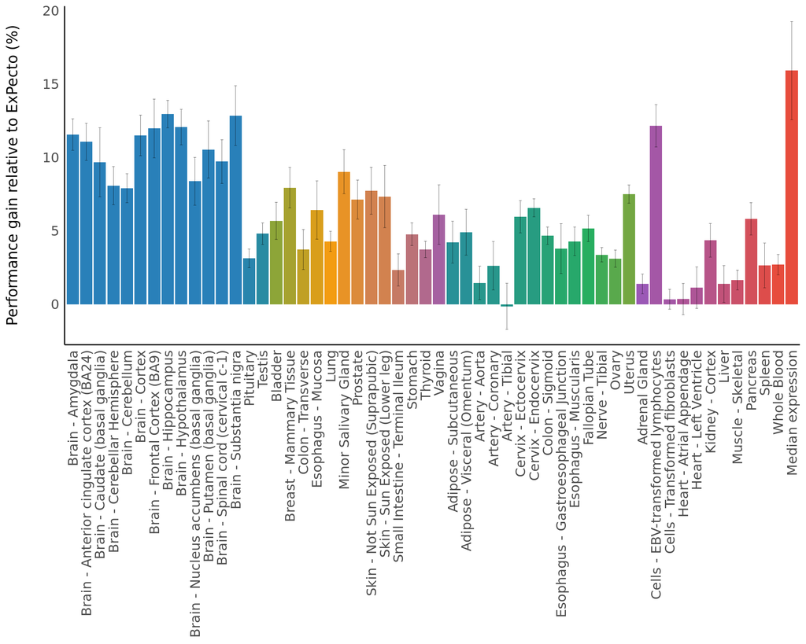

```r
cor_to_brain <- readRDS("./functions/cluster_color.rds")
# compute median RMSE across runs
res_rmse%>%
  group_by(tissue,model)%>%
  summarise(median_mad=mad(RMSE),
            RMSE=median(RMSE))%>%
  ungroup()%>%
  mutate(tissue=rename_tissue_bar(tissue),
         tissue=factor(tissue,levels=c(cor_to_brain$key, "Median expression" )))-> res_rmse_med

# generate bar plot for comparing RMSE between DEcode and ExPecto
res_rmse_med%>%
  filter(model=="ExPecto")%>%
  dplyr::select(-model,-median_mad)%>%
  dplyr::rename(Base_RMSE=RMSE)%>%
  inner_join(res_rmse_med,.,by=c("tissue"))%>%
  mutate(median_mad_bottom=(Base_RMSE-RMSE-median_mad)/Base_RMSE*100,
         median_mad_top=(Base_RMSE-RMSE+median_mad)/Base_RMSE*100,
         RMSE=(Base_RMSE-RMSE)/Base_RMSE*100)%>%
  filter(model=="DEcode")%>%#.$RMSE%>%mean
  ggplot(., aes(x=tissue, y=RMSE, fill=tissue)) +
  geom_bar(stat="identity") +
  geom_errorbar(aes(ymin=median_mad_bottom, ymax=median_mad_top), width=.2,
                position=position_dodge(.5),size=0.1)+
  theme_modern()+
  scale_fill_manual(values = c(cor_to_brain%>%.$color,"#E74C3C")) +
  #d5_fill()+
  theme(axis.text.x = element_text(angle = 90, hjust = 1,vjust = 0.5),
        legend.position = "none")+
  #coord_cartesian(ylim = c(0.7,2))+
  xlab(NULL)+
  ylab("Performance gain relative to ExPecto (%)")-> p

plot(p)
```

Performance comparison of DEcode with ExPecto with respect to correlation coefficient.

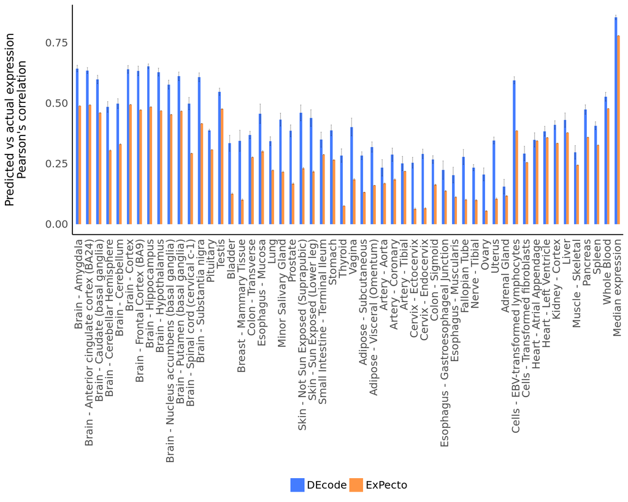

```r
# generate bar plot for comparing correlation between DEcode and ExPecto
res_cor%>%
  group_by(tissue,model)%>%
  summarise(median_mad=mad(estimate),
            estimate=median(estimate))%>%
  ungroup()%>%
  mutate(tissue=rename_tissue_bar(tissue),
         tissue=factor(tissue,levels=c(cor_to_brain$key, "Median expression" )))%>%
  ggplot(., aes(x=tissue, y=estimate, fill=model)) +
  geom_bar(stat="identity",
           position=position_dodge(),width = 0.5) +
  geom_errorbar(aes(ymin=estimate-median_mad, ymax=estimate+median_mad), width=.2,
                position=position_dodge(.5),size=0.1)+
  theme_modern()+
  d5_fill()+
  theme(axis.text.x = element_text(angle = 90, hjust = 1,vjust = 0.5),
        legend.position = "bottom")+
  #coord_cartesian(ylim = c(0.7,2))+
  xlab(NULL)+
  ylab("Predicted vs actual expression\nPearson's correlation")-> p
plot(p)
```

### Predictive performances of the models trained with a different set of features.

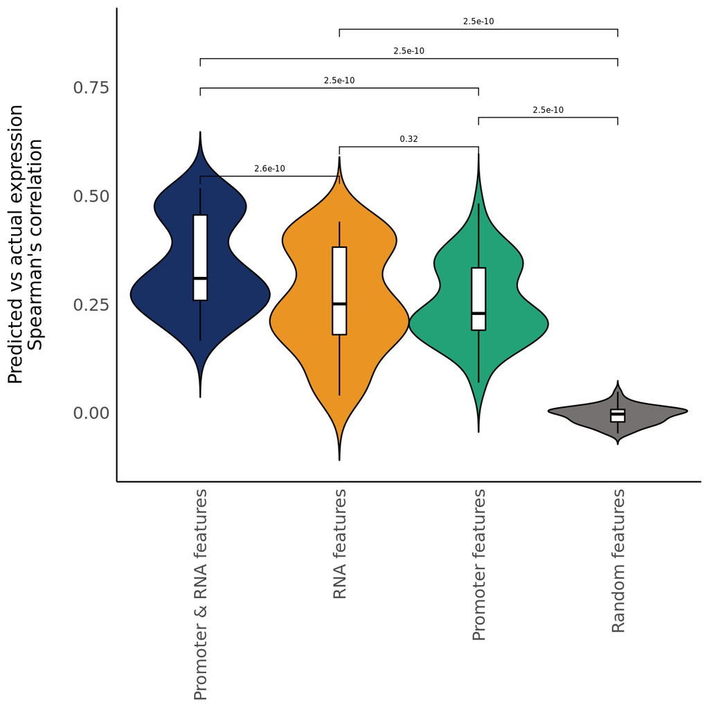

```r
ds <- readRDS("../data/01_tissue_gene/DEcode_model/test_Chr1/pred.rds")
ds$tissue=ds$tissue%>%rename_tissue_bar()
cor_to_brain <- readRDS("./functions/cluster_color.rds")

ds%>%
  filter(tissue!="Median expression")%>%
  group_by(tissue,model)%>%
  do(cor.test(.$actual,.$pred,method = "spearman")%>%broom::tidy())%>%
  ungroup()%>%
  mutate(model=c("Promoter & RNA features",
                 "RNA features",
                 "Promoter features",
                 "Random features")[match(model,
                                          c("Promoter & RNA features",
                                            "RNA features",
                                            "DNA features",
                                            "Random"))])%>%
  mutate(tissue=factor(tissue,levels = cor_to_brain$key))%>%
  mutate(model=factor(model,levels =
                      c("Promoter & RNA features",
                        "RNA features",
                        "Promoter features",
                        "Random features")))%>%
  arrange(tissue)%>%
  ggviolin(., x = "model", y = "estimate", fill = "model",scale="width",
           add = "boxplot", add.params = list(fill = "white",width=0.1))+
  stat_compare_means(paired = T,size=2,bracket.size = 0.3,
                     comparisons = list(c(1,2),c(2,3),c(3,4),
                                        c(1,3),c(1,4),c(2,4)))+
  theme_modern()+
  theme(legend.position = "none")+
  d6_fill(label = NULL)+
  ylab("|DeepLIFT score|")+
  xlab(NULL)+
  theme(axis.text.x = element_text(angle = 90, hjust = 1,vjust=0.5))+
  ylab("Predicted vs actual expression\nSpearman's correlation")-> p

plot(p)
```

### Comparison of predictors’ predictive contribution among classes of regulators.

Regulator’s predictive contribution to the fold-change across 53 tissues was estimated based on DeepLIFT score. The two-sample Wilcoxon test was used to assess the statistical significance of the differential contribution.

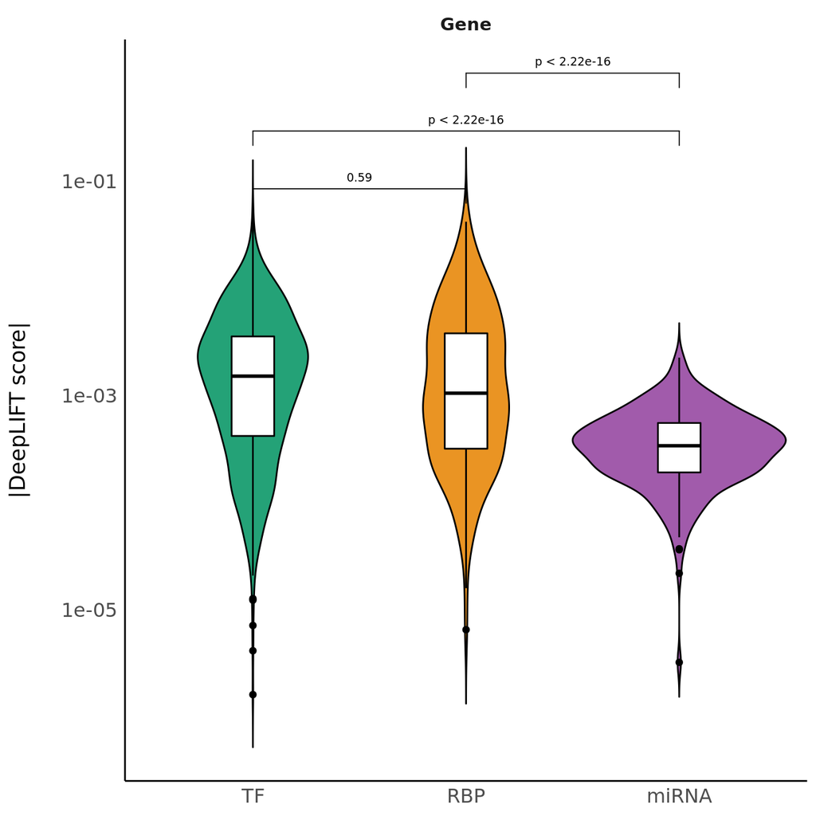

```r
# load DeepLIFT score
DeepLIFT_mean <- readRDS("../data/01_tissue_gene/DEcode_model/test_Chr1/DeepLIFT_mean.rds")

DeepLIFT_mean%>%
  filter(tissue_name!="MedianExp")%>%
  filter(Type!="other")%>%
  group_by(feat_name,Type)%>%
  summarise(shap_mean=mean(abs(shap_mean)))%>%
  ungroup()%>%
  arrange(desc(shap_mean))%>%
  mutate(feat_name=paste0(Type,"_",feat_name))%>%
  mutate(Var="Gene")-> ds

ds%>%
  group_by(Var)%>%
  mutate(shap_mean=replace(shap_mean,shap_mean==0,min(shap_mean[shap_mean>0]/2)))%>%
  mutate(Type=factor(Type,levels = c("TF","RBP","miRNA")))%>%
  ggviolin(., x = "Type", y = "shap_mean", fill = "Type",
           add = "boxplot", add.params = list(fill = "white"))+
  stat_compare_means(comparisons = list(c(1,2),c(1,3),c(2,3)),size=2.5)+
  scale_y_log10()+
  theme_modern(plot.title.size = 20)+
  facet_wrap(~Var,ncol = 1)+
  theme(legend.position = "none",
        strip.text.x = element_text(size = 11))+
  d3_fill(label = NULL)+
  ylab("|DeepLIFT score|")+
  xlab(NULL) -> p

plot(p)
```

## Key predictive regulators for the tissue-specific transcriptomes.

We selected the top 5 key predictors for each tissue and their DeepLIFT scores were displayed as a heatmap. The ward linkage method with the Euclidean distance was used to cluster tissues and predictors.

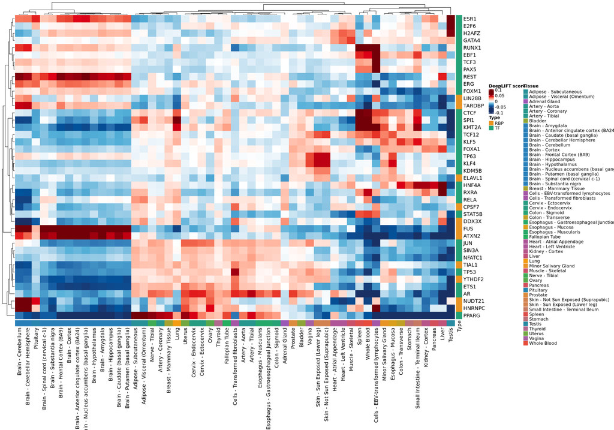

```r
# load DeepLIFT score
DeepLIFT_mean <- readRDS("../data/01_tissue_gene/DEcode_model/test_Chr1/DeepLIFT_mean.rds")%>%
  filter(tissue_name!="MedianExp",
         Type!="other")

# keep top5 influential regulators
DeepLIFT_mean%>%
  group_by(tissue_name)%>%
  arrange(desc(abs(shap_mean)))%>%
  filter((1:n())%in%c(1:5))%>%.$feat_name%>%unique()-> keep

DeepLIFT_mean%>%
  filter(feat_name%in%keep)%>%
  spread(tissue_name,shap_mean)->DeepLIFT_mean

# make DeepLIFT score matrix for clustering
Importance_mean_rowName=DeepLIFT_mean$feat_name
DeepLIFT_mean%>%
  dplyr::select(-feat_name,-Type)%>%
  as.matrix() -> Importance_mean_matrix
rownames(Importance_mean_matrix)=Importance_mean_rowName
colnames(Importance_mean_matrix) = colnames(Importance_mean_matrix)%>%rename_tissue_bar()


# color code
alphabet_order <- readRDS("../code/functions/cluster_color.rds")
tissue_color=alphabet_order$color
names(tissue_color)=alphabet_order$key
tissue_color=tissue_color[match(colnames(Importance_mean_matrix),names(tissue_color))]

# make column and row Annotation
tc = columnAnnotation(Tissue = names(tissue_color),
                      col = list(Tissue = tissue_color),
                      show_annotation_name = FALSE)
ha = rowAnnotation(Type = DeepLIFT_mean$Type,
                   col = list(Type = c("TF" = "#24A277", "RBP" = "#EA9423")))

# generate heatmap
Importance_mean_matrix%>%
  Heatmap(cluster_rows = TRUE,cluster_columns = TRUE,
          right_annotation = ha,
          bottom_annotation = tc,
          clustering_method_rows="ward.D2",
          clustering_method_columns="ward.D2",
          col = g2_colorRamp2(values = seq(from=-0.06,to=0.06,0.12/6)),
          column_names_max_height = unit(20,"cm"),
          name = "DeepLIFT score")->p
show(p)
```